# 101. LSSTCam visits database

For the Rubin Science Platform at data.lsst.cloud.  
Container Size: Large  
LSST Science Pipelines version: v29.2.0  
Last verified to run: 2026-06-09  
Repository: github.com/lsst/tutorial-notebooks  
DOI: 10.11578/rubin/dc.20250909.20

**Learning objective:** How to query and retrieve data from the temporary LSSTCam visits database file.

**LSST data products:** The file `prelsst_20260607_visits.db` has been made temporarily available until it is superseded by upcoming data releases.

**Packages:** `sqlite3`, `rubin_sim`

**Credit:** Developed by the Rubin Community Science team together with the Rubin Survey Scheduling team. Please consider acknowledging them if this notebook is used for the preparation of journal articles, software releases, or other notebooks.

**Get Support:** Everyone is encouraged to ask questions or raise issues in the [Support Category](https://community.lsst.org/c/support) of the Rubin Community Forum. Rubin staff will respond to all questions posted there.

## 1. Introduction

This tutorial demonstrates how to query and load data from a temporary SQL-formatted table of LSSTCam visits that is available in the Rubin Science Platform. An early version of this file, for visits up to the end of September 2025, was first made available on the [Science Validation survey summary webpage](https://survey-strategy.lsst.io/progress/sv_status/sv_20250930.html) . **This is a temporary, static database file with non-standard schema and formatting. It only includes LSSTCam visit metadata from April 2025 to June 2026.** For more recent visits and a forecast of the Rubin scheduler, see the tutorial notebook for the Rubin Schedule Viewer. The future Rubin data releases will have similar information in their `Visit` and `CcdVisit` tables.

**Science Validation surveys.**

**Pre-LSST, AOS commissioning, and engineering visits.**

Throughout the first half of 2026, pre-LSST visits were obtained in the DDFs where templates exist, for the purpose of alert production, and for engineering and Active Optics System (AOS) commissioning with the goal of reaching stable image quality metrics which meet the conditions for starting the LSST. Many of the latter visits have been tagged as suitable for science (pending processing and science validation).

**Caveats.**

- **Not all of these visits lead to scientifically validated data products.** Some will end up excluded from the DP2 and the Prompt Products datasets. Although an initial cut of bad visits have been made on the inputs to the database, users should expect that additional cuts post-processing.
- **Image quality (IQ) is variable.** The database file excludes bad visits, but includes visits with a wide range of data quality due to both cloud extinction and/or delivered IQ or engineering issues. Keep in mind that while these visits were obtained, the AOS was being commissioned.
- **Measured IQ values may change.** Some columns contain NaNs, where the summit quicklook processing did not provide a useful value. Many of these problems will be resolved with later processing. Users should anticipate that some measured IQ values will change.

### 1.1. Import packages

Import `sqlite3` to read the SQL-formatted database file, and import the `maf` module from the `rubin_sim` package to use the ([Metric Analysis Framework](https://rubin-sim.lsst.io/maf.html)) functions. Import the `skyproj` package ([skyproj.readthedocs.io](https://skyproj.readthedocs.io/en/latest/)) for plotting all-sky projection plots, the `healpy` package ([healpy.readthedocs.io](https://healpy.readthedocs.io/en/latest/)) for dealing with HEALPix. Also import standard python science packages and the `lsst.utils.plotting` package.

```python
import sqlite3
from rubin_sim import maf

import skyproj
import healpy as hp

import os
import matplotlib.pyplot as plt
import numpy as np
import pandas as pd
import astropy.units as u
from astropy.coordinates import SkyCoord
from tabulate import tabulate
from astropy.time import Time
from lsst.utils.plotting import (get_multiband_plot_colors,
                                 get_multiband_plot_linestyles)
```

### 1.2. Define parameters

Define the path and name of the database file.

```python
db_filename = '/rubin/cst_repos/tutorial-notebooks-data/data/prelsst_20260607_visits.db'
```

Define the default path for output files. Use the shared scratch directory, `/deleted-sundays/`, and create a subdirectory with your username if one does not already exist.

```python
output_path = os.getenv('SCRATCH_DIR')
if os.path.exists(output_path):
    print('Already exists: ', output_path)
else:
    os.system('mkdir ' + output_path)
    print('Created: ', output_path)
```

```
Already exists:  /deleted-sundays/melissagraham
```

Define the LSST filter names and the colors and linestyles to represent the filters.

```python
filter_names = ['u', 'g', 'r', 'i', 'z', 'y']
filter_colors = get_multiband_plot_colors()
filter_linestyles = get_multiband_plot_linestyles()
filter_colors_list = [filter_colors['u'], filter_colors['g'],
                      filter_colors['r'], filter_colors['i'],
                      filter_colors['z'], filter_colors['y']]
```

## 2. Explore the database

The information contained in the database is an aggregation of entries in the "Consolidate Database" (ConsDB), including per-visit summary values from summit quicklook processing (the ConsDB is not yet released to users). The database generally follows the current LSST scheduler output schema, but additional columns were added in post-processing. Rubin data releases have similar information in their `Visit` and `CcdVisit` tables.

As this is an aggregate file, descriptions for its columns can be found among those at:

- [ConsDB Schema](https://sdm-schemas.lsst.io/cdb_lsstcam.html)
- [Scheduler Output Schema](https://rubin-scheduler.lsst.io/fbs-output-schema.html)

### 2.1. Key columns

The database contains many columns, but these are the key columns used in this tutorial.

- `observation_reason` : The source of the visit in the Feature Based Scheduler (FBS).
- `target_name` : The name of the sky region for the visit.
- `exp_midpt_mjd` : The midpoint time of the exposure at the fiducial center of the focal plane (in TAI).
- `fieldRA` : The boresight Right Ascension for the visit (degrees).
- `fieldDec` : The boresight Declination for the visit (degrees).
- `band` : The LSST filter used for the visit, one of $ugrizy$.
- `airmass` : The airmass of the visit ($1/\cos(\Theta_z)$, where $\Theta_z$ is the zenith angle).
- `seeingFwhmEff` : The full-width half-max of the point spread function (PSF; arcseconds).
- `fiveSigmaDepth` : The magnitude of a five-sigma point source detection in the visit (magnitudes).

### 2.2. Connect with sqlite3

Connect to the database file using `sqlite3`.

```python
db_conn = sqlite3.connect(db_filename)
cursor = db_conn.cursor()
```

Print the names of all tables in the database. There is only one, the `observations` table.

```python
cursor.execute("SELECT name FROM sqlite_master WHERE type='table';")
tables = cursor.fetchall()
table_names = [table[0] for table in tables]
print("Tables:", table_names)
del tables, table_names
```

```
Tables: ['observations']
```

Option to print the schema (column names and types) for the `observations` table. It is a long list, and not printed by default.

```python
# table_name = 'observations'
# query = f"""SELECT sql FROM sqlite_master WHERE type='table'
#             AND name='{table_name}';"""
# cursor.execute(query)
# create_table_sql = cursor.fetchone()[0]
# print(f"Schema for {table_name}:\n{create_table_sql}")
# del query, table_name, create_table_sql
```

**Example query.**

As an example, create a query to return columns `fieldRA`, `fieldDec`, and `band` from the `observations` table for all $r$-band visits obtained at an airmass less than 1.5 and with an `observation_reason` of "field_survey_science". The column `observation_reason` is discussed in Section 3.1.

```python
query = """SELECT fieldRA, fieldDec, band FROM observations
           WHERE observation_reason = 'field_survey_science'
           AND band='r' AND airmass < 1.5; """
cursor.execute(query)
results = cursor.fetchall()
print("Number of rows returned: ", len(results))
```

```
Number of rows returned:  1463
```

Option to display the query results.

```python
# results
```

Clean up, and close the connection with the database.

```python
del query, results
cursor.close()
del cursor
```

### 2.3. Read as a pandas dataframe

The file is small enough to be loaded in its entirety as a `pandas` dataframe.

Read the SQL-formatted table as a pandas dataframe, `df`, and print the number of rows.

```python
df = pd.read_sql_query("SELECT * FROM observations", db_conn)
print(len(df))
```

```
81454
```

Option to display the table (it will automatically truncate).

```python
# df
```

Option to print the column names.

```python
# list(df.columns)
```

## 3. Observation reason and target

There are a few rows of the database that indicate the *motivation* behind each observation (each visit). All rows of the visits database have `img_type` = `science`, but as explained in Section 1 this does not necessarily mean they will pass science validation and be released. The column `science_program` is an internal designation, `BLOCK-XXX`, and probably not useful for most users.

Every visit has both an `observation_reason` and a `target_name`, and these are useful to explore.

### 3.1. Observation reason

The `observation_reason` is the motivation as to why the visit was obtained. In other words, it indicates the scheduler mode or the survey.

Option to print *all* unique values of the `observation_reason` column and the number of visits for each.

> **Warning:** The feature-based scheduler (FBS) and Rubin operations were in the early stages when these visits were obtained, and the values of the `observation_reason` column exhibit diversity; explanations for every single value are not provided at this time.

```python
# values, counts = np.unique(df['observation_reason'], return_counts=True)
# for value, count in zip(values, counts):
#     print('%25s %5i' % (value, count))
# del values, counts
```

Print the number of visits done for small field surveys, deep drilling fields, target of opportunity, AOS commissioning, and alert production.

```python
Nsfs = len(df.query("observation_reason == 'field_survey_science'"))
Nddf = len(df.query("observation_reason.str.contains('ddf')"))
Ntoo = len(df.query("observation_reason.str.contains('too')"))
Naos = len(df.query("observation_reason.str.contains('aos')"))
Nalrt = len(df.query("observation_reason.str.contains('alert')"))
print("Number of visits done for")
print("small field surveys:    ", Nsfs)
print("deep drilling fields:   ", Nddf)
print("target of opportuntity: ", Ntoo)
print("AOS commissioning:      ", Naos)
print("alert production:       ", Nalrt)
del Nsfs, Nddf, Ntoo, Naos, Nalrt
```

```
Number of visits done for
small field surveys:     6995
deep drilling fields:    2486
target of opportuntity:  1003
AOS commissioning:       10262
alert production:        2719
```

### 3.2. Target names

The `target_name` is either a region of the LSST WFD (e.g., bulge, low-dust) or a proper name (for DDFs, or the commissioning small field survey fields). Since regions can overlap, or a single visit can overlap the boundaries of multiple regions, the `target_name` is often a comma-separated list. For example, most DDFs are also in the low-dust extragalactic regions of the LSST WFD.

**Small field surveys.**

Get the unique values of `target_name` for each of the small field survey areas, and print the number of visits done for each.

```python
df_sfs = df.query("observation_reason == 'field_survey_science'")
values, counts = np.unique(df_sfs['target_name'], return_counts=True)
for value, count in zip(values, counts):
    print('%20s %5i' % (value, count))
del df_sfs, values, counts
```

```
          Abell_2764     7
              COSMOS   659
         DESI_SV3_R1     4
            ELAIS_S1   166
                 M49  1105
        New_Horizons   359
               Prawn   621
     Rubin_SV_212_-7   496
    Rubin_SV_216_-17   121
    Rubin_SV_225_-40  2346
    Rubin_SV_280_-48   148
    Rubin_SV_300_-41    38
    Rubin_SV_320_-15   257
       Trifid-Lagoon   668
```

**Wide-fast-deep regions.**

Option to print the `target_name` for all visits that were *not* done with an `observation_reason` related to the small field surveys, the deep drilling fields, or targets of opportunity - the result will be inclusive of all WFD sky regions.

```python
# query = "(observation_reason != 'field_survey_science') & "
# query += "(observation_reason.str.contains('ddf') == 0) & "
# query += "(observation_reason.str.contains('too') == 0) "
# df_wfd = df.query(query)

# print("All target_name values, omitting non-WFD observation reasons.")
# values, counts = np.unique(df_wfd['target_name'], return_counts=True)
# for value, count in zip(values, counts):
#     print('%30s %5i' % (value, count))
# print(" ")
# print("Unique target_name values for WFD observation reasons.")
# temp = []
# for value in values:
#     for name in str(value).split(','):
#         temp.append(name.strip())
# targets = np.unique(temp)
# print(targets)

# del query, values, counts, temp, targets, df_wfd
```

The WFD sky regions covered during commissioning are:

- `LMC_SMC` - Large and Small Magellanic Clouds
- `bulgy` - Galactic bulge region
- `dusty_plane` - dusty regions of the Galactic plane
- `euclid_overlap` - overlap with Euclid space telescope field overlap
- `field_m49` and `virgo` - Virgo cluster
- `lowdust` - low dust sky region
- `nes` - North Ecliptic Spur (NES)
- `scp` - south celestial pole

Learn more about all of the planned LSST WFD regions on the [LSST Baseline Strategy webpage](https://survey-strategy.lsst.io/baseline/index.html).

> **Notice:** These WFD sky regions are not mutually exclusive; the Euclid fields are within the low-dust WFD region, for example, just like the DDFs are.

List the number of visits that overlap with each WFD sky region. As sky regions are not mutually exclusive, the sum is greater than the total number of visits.

```python
WFD_targets = ['LMC_SMC', 'bulgy', 'dusty_plane', 'euclid_overlap',
               'field_m49', 'lowdust', 'nes', 'scp', 'virgo']
for target in WFD_targets:
    print('%15s %5i' % (target, len(df.query("target_name.str.contains(@target)"))))
del WFD_targets
```

```
        LMC_SMC   736
          bulgy  8649
    dusty_plane  9582
 euclid_overlap   203
      field_m49   648
        lowdust 46164
            nes  1608
            scp  2038
          virgo   115
```

**Deep Drilling Fields.**

The LSST will include five [Deep Drilling Fields](https://survey-strategy.lsst.io/baseline/ddf.html), four of which (all except COSMOS) were observed as part of the LSST Science Validation survey. Note the EDFS (Euclid Deep Field South) field is actually two side-by-side fields.

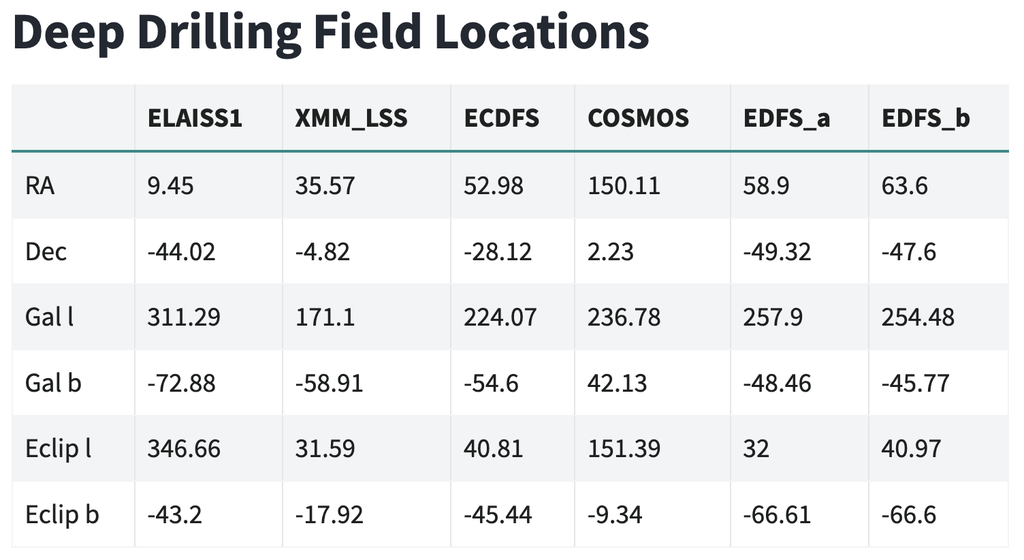

> **Table 1:** DDF locations, from [the DDF webpage](https://survey-strategy.lsst.io/baseline/ddf.html#deep-drilling-field-locations).

Option to print the `target_name` for all visits that were done with an `observation_reason` related to the deep drilling fields.

```python
# df_ddf = df.query("observation_reason.str.contains('ddf')")

# print("All target_name values with DDF observation reasons.")
# values, counts = np.unique(df_ddf['target_name'], return_counts=True)
# for value, count in zip(values, counts):
#     print('%30s %5i' % (value, count))
# print(" ")
# print("Unique target_name values for DDF observation reasons.")
# temp = []
# for value in values:
#     for name in str(value).split(','):
#         temp.append(name.strip())
# targets = np.unique(temp)
# print(targets)

# del values, counts, temp, targets, df_ddf
```

The naming convention for the DDFs has changed since the start of LSSTCam observations.

- `DDF ECDFS` --> `ddf_ecdfs`
- `DDF EDFS_a` --> `ddf_edfs_a`
- `DDF EDFS_b` --> `ddf_edfs_b`
- `DDF ELAISS1` --> `ddf_elaiss1`
- `DDF XMM_LSS` --> `ddf_xmm_lss`

Standardize the `target_name` strings for DDF-related visits.

```python
df['target_name'] = df['target_name'].str.replace('DDF ECDFS', 'ddf_ecdfs', regex=False)
df['target_name'] = df['target_name'].str.replace('DDF EDFS_a', 'ddf_edfs_a', regex=False)
df['target_name'] = df['target_name'].str.replace('DDF EDFS_b', 'ddf_edfs_b', regex=False)
df['target_name'] = df['target_name'].str.replace('DDF ELAISS1', 'ddf_elaiss1', regex=False)
df['target_name'] = df['target_name'].str.replace('DDF XMM_LSS', 'ddf_xmm_lss', regex=False)
```

List the number of visits that overlap with each DDF sky region.

```python
DDF_targets = ['ddf_cosmos', 'ddf_ecdfs', 'ddf_edfs_a', 'ddf_edfs_b', 'ddf_elaiss1', 'ddf_xmm_lss']
for target in DDF_targets:
    print('%15s %5i' % (target, len(df.query("target_name.str.contains(@target)"))))
del DDF_targets
```

```
     ddf_cosmos  1633
      ddf_ecdfs   490
     ddf_edfs_a   729
     ddf_edfs_b   717
    ddf_elaiss1   850
    ddf_xmm_lss   214
```

## 4. Visit metadata

Examples of how to visualize and calculate statistics for a few key columns of visit metadata.

### 4.1. Plot histograms

Create a histogram of the Modified Julian Dates of all visits, stacked by filter.

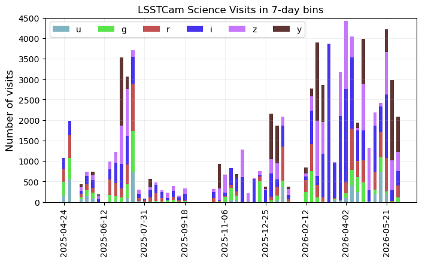

```python
t = Time("2025-04-17T12:00:00", scale='tai')
mjd_to_jd = t.mjd - t.jd
df.loc[:, 'jd'] = np.floor(df.observationStartMJD - mjd_to_jd)
df.loc[:, 'jd'] = df.jd.astype(int)
jds = np.arange(df.jd.min(), df.jd.max()+1, 7)
jdsbins = np.arange(df.jd.min(), df.jd.max()+7, 7)
days = [t.split('T')[0] for t in Time(jds, format='jd', scale='tai').isot]
bar_bottom = np.zeros(len(jds))

plt.figure(figsize=(8, 4))
for b in 'ugrizy':
    heights, _ = np.histogram(df.query("band == @b ").jd, bins=jdsbins)
    plt.bar(jds, heights, bottom=bar_bottom, width=4, color=filter_colors[b], alpha=0.8, label=b)
    bar_bottom += heights
plt.legend(loc='upper left', ncol=6)
_ = plt.xticks(jds[::7], labels=days[::7], rotation=90)
plt.grid(alpha=0.2)
plt.ylabel("Number of visits", fontsize='large')
plt.ylim([0, 4500])
plt.title("LSSTCam Science Visits in 7-day bins")
plt.show()
```

> **Figure 1:** The number of visits over time, stacked by filter, in 7-day bins.

Create a histogram of the airmass of each visit, by filter.

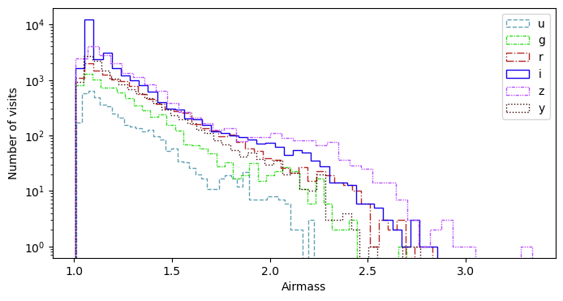

```python
fig = plt.figure(figsize=(8, 4))
for f, filt in enumerate(filter_names):
    plt.hist(df.query("band == @filt")['airmass'],
             bins=40, histtype='step', log=True,
             ls=filter_linestyles[filt],
             color=filter_colors_list[f], label=filt)
plt.legend(loc='best')
plt.xlabel("Airmass")
plt.ylabel("Number of visits")
plt.show()
```

> **Figure 2:** The number of visits in bins of airmass, by filter.

Create a histogram of the measured seeing of each visit, by filter.

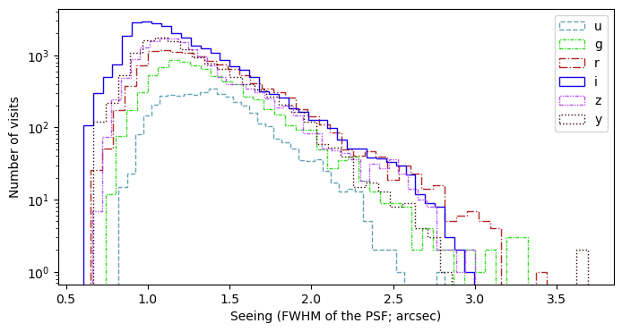

```python
fig = plt.figure(figsize=(8, 4))
for f, filt in enumerate(filter_names):
    plt.hist(df.query("band == @filt")['seeingFwhmEff'],
             bins=40, histtype='step', log=True,
             ls=filter_linestyles[filt],
             color=filter_colors_list[f], label=filt)
plt.legend(loc='best')
plt.xlabel("Seeing (FWHM of the PSF; arcsec)")
plt.ylabel("Number of visits")
plt.show()
```

> **Figure 3:** The number of visits in bins of seeing, by filter.

Create a histogram of the $5\sigma$ depth (for point sources) of each visit, by filter.

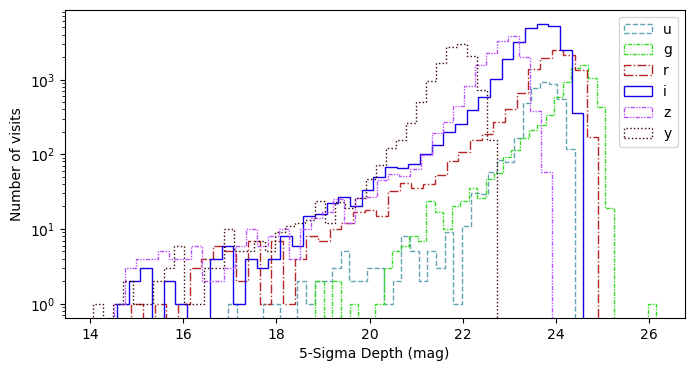

```python
fig = plt.figure(figsize=(8, 4))
for f, filt in enumerate(filter_names):
    plt.hist(df.query("band == @filt")['fiveSigmaDepth'],
             bins=40, histtype='step', log=True,
             ls=filter_linestyles[filt],
             color=filter_colors_list[f], label=filt)
plt.legend(loc='best')
plt.xlabel("5-Sigma Depth (mag)")
plt.ylabel("Number of visits")
plt.show()
```

> **Figure 4:** The number of visits in bins of 5$\sigma$ depth for point sources, by filter.

### 4.2. Summary statistics

Recreate parts of the tables on the [Science Validation survey summary webpage](https://survey-strategy.lsst.io/progress/sv_status/sv_20250930.html#sv-wide). This section uses code from the LSSTCam summary notebook in the [Sims SV Survey repo](https://github.com/lsst-sims/sims_sv_survey/blob/main/notebooks/lsstcam_summary.ipynb).

**Small field survey areas.**

Display a table of the number of visits by band for each of the small field survey areas with at least 50 visits total.

```python
query = "observation_reason == 'field_survey_science'"
df_sfs = df.query(query).groupby(['target_name', 'band']).agg({'seq_num': 'count'})
df_sfs.rename({'seq_num': 'count'}, axis=1, inplace=True)
df_sfs = df_sfs.reset_index('band').pivot(columns=["band"]).droplevel(0, axis=1)
df_sfs = df_sfs[['u', 'g', 'r', 'i', 'z', 'y']]
df_sfs['all'] = df_sfs.sum(axis=1)
df_sfs = df_sfs.query("all > 50").sort_values('all')
table = tabulate(pd.DataFrame(df_sfs.round(0)), headers='keys')
table = table.replace('nan', '  0')
print('Number of visits, for small fields with at least 50 visits total.')
print(table)
del query, df_sfs, table
```

```
Number of visits, for small fields with at least 50 visits total.
target_name         u    g    r    i    z    y    all
----------------  ---  ---  ---  ---  ---  ---  -----
Rubin_SV_216_-17    0   28   30   63    0    0    121
Rubin_SV_280_-48   30   30   29   30   29    0    148
ELAIS_S1           11   30   30   30   35   30    166
Rubin_SV_320_-15    0   24   17   99   83   34    257
New_Horizons       36   48   70  108   74   23    359
Rubin_SV_212_-7     0  139  234  123    0    0    496
Prawn             196  160  142   93   30    0    621
COSMOS             96   82  166  139  110   66    659
Trifid-Lagoon     235  196  122  115    0    0    668
M49               234  280  378  213    0    0   1105
Rubin_SV_225_-40  343  559  480  470  330  164   2346
```

Display a table of the number of visits, median seeing (FWHM), mean airmass, and timespan (time between first and last visit) for each of the small field survey areas with at least 50 visits total.

```python
query = "observation_reason == 'field_survey_science'"
df_sfs = df.query(query).groupby(['target_name']).agg({'seq_num': 'count',
                                                       'seeingFwhmEff': 'median',
                                                       'airmass': 'mean',
                                                       'exp_midpt_mjd': np.ptp})
df_sfs.rename({'seq_num': 'nvisits',
               'seeingFwhmEff': 'median fwhm (arcsec)',
               'airmass': 'mean airmass',
               'exp_midpt_mjd': 'timespan (days)'}, axis=1, inplace=True)
df_sfs = df_sfs.query("nvisits > 50").sort_values('nvisits')
df_sfs['timespan (days)'] = df_sfs['timespan (days)'].astype(int) + 1
df_sfs.round(2)
table = tabulate(pd.DataFrame(df_sfs.round(2)), headers='keys')
table = table.replace('nan', '  0')
print(table)
del query, df_sfs, table
```

```
target_name         nvisits    median fwhm (arcsec)    mean airmass    timespan (days)
----------------  ---------  ----------------------  --------------  -----------------
Rubin_SV_216_-17        121                    1.39            1.09                  2
Rubin_SV_280_-48        148                    1.71            1.62                  1
ELAIS_S1                166                    1.59            1.03                 17
Rubin_SV_320_-15        257                    1.33            1.08                  6
New_Horizons            359                    1.17            1.1                  62
Rubin_SV_212_-7         496                    1.33            1.26                  7
Prawn                   621                    1.55            1.2                  79
COSMOS                  659                    1.38            1.41                 15
Trifid-Lagoon           668                    1.28            1.15                 10
M49                    1105                    1.44            1.34                 10
Rubin_SV_225_-40       2346                    1.42            1.17                334
```

**Deep drilling fields.**

Make similar versions of the two tables above, but for the DDFs.

First, create a new column that contains only the DDF name, for visits of a DDF (and is a null string otherwise).

```python
df['target_name_ddf'] = df['target_name']
df.loc[~df['target_name_ddf'].str.contains("ddf"), 'target_name_ddf'] = ''
df['target_name_ddf'] = df['target_name_ddf'].str.replace(', lowdust', '', regex=False)
df['target_name_ddf'] = df['target_name_ddf'].str.replace('lowdust, ', '', regex=False)
```

For visits of DDF with >50 visits, display tables similar to the above.

```python
query = "target_name_ddf.str.contains('ddf')"
df_ddf = df.query(query).groupby(['target_name_ddf', 'band']).agg({'seq_num': 'count'})
df_ddf.rename({'seq_num': 'count'}, axis=1, inplace=True)
df_ddf = df_ddf.reset_index('band').pivot(columns=["band"]).droplevel(0, axis=1)
df_ddf = df_ddf[['u', 'g', 'r', 'i', 'z', 'y']]
df_ddf['all'] = df_ddf.sum(axis=1)
df_ddf = df_ddf.query("all > 50").sort_values('all')
table = tabulate(pd.DataFrame(df_ddf.round(0)), headers='keys')
table = table.replace('nan', '  0')
print(table)
del query, df_ddf, table
```

```
target_name_ddf      u    g    r    i    z    y    all
-----------------  ---  ---  ---  ---  ---  ---  -----
ddf_xmm_lss         71   21   18   54   26   24    214
ddf_ecdfs           47  101   85  140   84   33    490
ddf_edfs_b          21  153  151  215  156   20    716
ddf_edfs_a          31  151  159  218  152   17    728
ddf_elaiss1         82  165  136  229  154   74    840
ddf_cosmos          88  315  310  556  301   63   1633
```

```python
query = "target_name_ddf.str.contains('ddf')"
df_ddf = df.query(query).groupby(['target_name_ddf']).agg({'seq_num': 'count',
                                                           'seeingFwhmEff': 'median',
                                                           'airmass': 'mean',
                                                           'exp_midpt_mjd': np.ptp})
df_ddf.rename({'seq_num': 'nvisits',
               'seeingFwhmEff': 'median fwhm (arcsec)',
               'airmass': 'mean airmass',
               'exp_midpt_mjd': 'timespan (days)'}, axis=1, inplace=True)
df_ddf = df_ddf.sort_values('nvisits')
df_ddf['timespan (days)'] = df_ddf['timespan (days)'].astype(int) + 1
df_ddf.round(2)
df_ddf = df_ddf.query("nvisits > 50").sort_values('nvisits')
table = tabulate(pd.DataFrame(df_ddf.round(2)), headers='keys')
table = table.replace('nan', '  0')
print(table)
del query, df_ddf, table
```

```
target_name_ddf      nvisits    median fwhm (arcsec)    mean airmass    timespan (days)
-----------------  ---------  ----------------------  --------------  -----------------
ddf_xmm_lss              214                    1.31            1.47                193
ddf_ecdfs                490                    1.39            1.48                240
ddf_edfs_b               716                    1.2             1.38                240
ddf_edfs_a               728                    1.21            1.41                240
ddf_elaiss1              840                    1.49            1.43                213
ddf_cosmos              1633                    1.11            1.31                174
```

## 5. MAF sky maps

The commissioning visits database file has been generated using the same format and schema as the Operations Simulations (opsim) databases, and so can be read by the MAF (Metric Analysis Frameworks) package from the `rubin_sim` package. This section follows the Jupyter Notebook tutorial for visualizing the survey footprint in the [rubin_sim_notebook repository](https://github.com/lsst/rubin_sim_notebooks).

Set the path to the folder containing `rubin_sim` data in the RSP at data.lsst.cloud.

```python
os.environ['RUBIN_SIM_DATA_DIR'] = '/rubin/rubin_sim_data'
```

Define the "opsim" filename and the "run name" -- in this case, the name of the commissioning visits database.

```python
opsim_fname = db_filename
temp = db_filename.split('/')[-1]
run_name = temp.split('.')[0]
print(run_name)
```

```
prelsst_20260607_visits
```

Define the metric to be plotted, in this case, `Nvisits`: the number of visits. Define the size (`nside`) of the `healpix` to use for the map. Do not define any constraints, and include all visits.

```python
metric = maf.metrics.CountMetric(col='observationStartMJD',
                                 metric_name='Nvisits')
nside = 64
slicer = maf.slicers.HealpixSlicer(nside=nside)
constraint = None
```

```
Healpix slicer using NSIDE=64, approximate resolution 54.967783 arcminutes
```

Bundle together the components of the metric.

```python
bundle = maf.MetricBundle(metric, slicer, constraint, run_name=run_name)
```

Define the bundle group to plot.

```python
group = maf.MetricBundleGroup({'nvisits': bundle},
                              opsim_fname, out_dir=output_path)
```

Calculate the metric. The following step will generate the files starting with `prelsst_20260607` in the `output_path` defined in Section 1.2.

```python
group.run_all()
```

Show the plots for this metric.

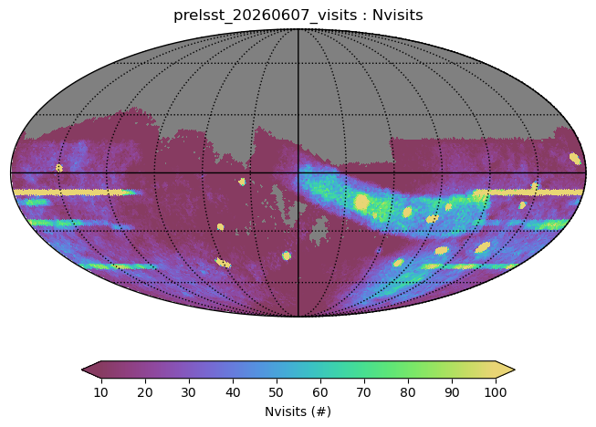

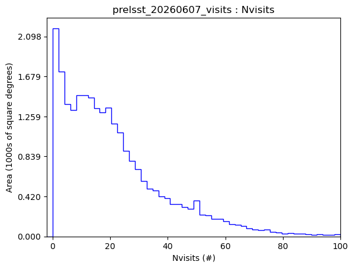

```python
plot_dict = {'color_min': 10, 'color_max': 100,
             'x_min': -2, 'x_max': 100, 'bins': 50, 'extend': 'both'}
bundle.set_plot_dict(plot_dict)
_ = bundle.plot()
```

> **Figure 5:** Top, the sky map of the number of visits obtained during commissioning. Bottom, the sky area binned by number of visits, showing that most of the commissioning area was shallow.

Read more about they sky coverage for the SV wide-area survey on the [Science Validation survey summary webpage](https://survey-strategy.lsst.io/progress/sv_status/sv_20250930.html#sv-wide) .

**AOS testing visits.**

In the top panel of Figure 5, stripes of visits with constant declination stand out in the sky distribution. The cause of this non-LSST-like survey pattern is in their observation reason: "fbs_driven_aos_stability_test". FBS stands for "feature-based scheduler" and AOS for "active optics system". These visits were obtained by the FBS for the purpose of testing the AOS, but are still anticipated to be, potentially, scientifically useful.

Visualize only the FBS AOS testing visits.

```python
constraint = "observation_reason like \'%aos%\'"
bundle = maf.MetricBundle(metric, slicer, constraint, run_name=run_name)
group = maf.MetricBundleGroup({'nvisits': bundle},
                              opsim_fname, out_dir=output_path)
group.run_all()
```

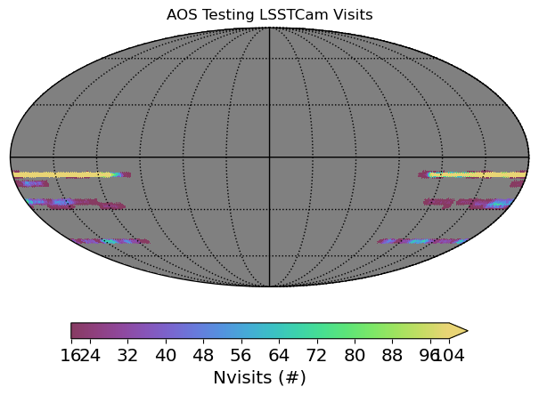

```python
ph = maf.PlotHandler(savefig=False, fig_format='png', thumbnail=False, dpi=270)
ph.set_metric_bundles([bundle])
ph.plot(plot_func=maf.plots.HealpixSkyMap(),
        plot_dicts={'color_min': 20, 'color_max': 100, 'figsize': (6, 4),
                    'labelsize': 'x-large', 'fontsize': 'x-large', 'extend': 'max',
                    'title': 'AOS Testing LSSTCam Visits'})
plt.show()
```

> **Figure 6:** The FBS AOS testing visits.

**DDF visits.**

Create a sky map for only the DDFs.

```python
constraint = "observation_reason like \'%ddf%\'"
bundle = maf.MetricBundle(metric, slicer, constraint, run_name=run_name)
group = maf.MetricBundleGroup({'nvisits': bundle},
                              opsim_fname, out_dir=output_path)
group.run_all()
```

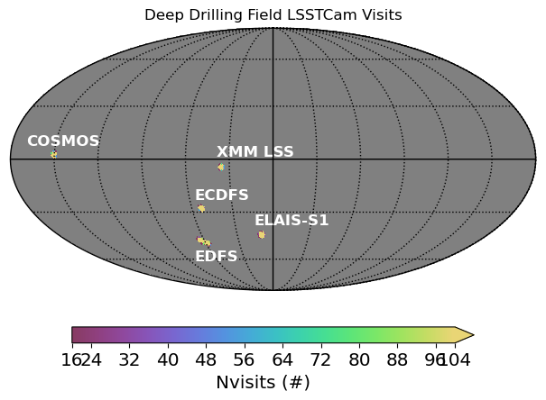

```python
ph = maf.PlotHandler(savefig=False, fig_format='png', thumbnail=False, dpi=270)
ph.set_metric_bundles([bundle])
ph.plot(plot_func=maf.plots.HealpixSkyMap(),
        plot_dicts={'color_min': 20, 'color_max': 100, 'figsize': (6, 4),
                    'labelsize': 'x-large', 'fontsize': 'x-large', 'extend': 'max',
                    'title': 'Deep Drilling Field LSSTCam Visits'})
plt.figtext(0.40, 0.62, 'XMM LSS', fontsize='large', fontweight='bold', color='white')
plt.figtext(0.36, 0.50, 'ECDFS', fontsize='large', fontweight='bold', color='white')
plt.figtext(0.36, 0.33, 'EDFS', fontsize='large', fontweight='bold', color='white')
plt.figtext(0.47, 0.43, 'ELAIS-S1', fontsize='large', fontweight='bold', color='white')
plt.figtext(0.05, 0.65, 'COSMOS', fontsize='large', fontweight='bold', color='white')
plt.show()
```

> **Figure 7:** The locations of the five Deep Drilling Fields (DDFs), with their names labeled.

## 6. Might my target be covered?

Define two sets of coordinates for two hypothetical targets. The first has been covered by LSSTCam visits and the second has not.

```python
target1_ra, target1_dec = 330.0, -10.0
target2_ra, target2_dec = 330.0, +10.0
```

To show the location of the two targets on the sky on top of a 2D density plot of the number of visits, instead of using the MAF metric to plot the sky map (as above), use the `healpy` and `skyproj` packages.

Use the `healpy` package to show that the area of one 19-sided HEALPix is similar to the LSSTCam FOV of 9.6 square degrees.

```python
print('One 19-sided HEALPix is ', np.round(hp.nside2pixarea(19, degrees=True), 2),
      ' square degrees.')
print('It takes ', int(41253.0 / hp.nside2pixarea(19, degrees=True)),
      ' 19-sided HEALPix to cover the full sky.')
```

```
One 19-sided HEALPix is  9.52  square degrees.
It takes  4332  19-sided HEALPix to cover the full sky.
```

Create the 2D distribution of LSSTCam visits and mark the locations of the two targets.

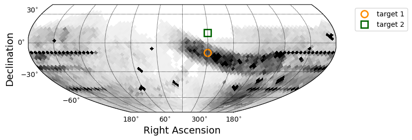

```python
fig, ax = plt.subplots(figsize=(8, 6))
sp = skyproj.McBrydeSkyproj(ax=ax)
vras = np.asarray(df['fieldRA'], dtype='float')
vdecs = np.asarray(df['fieldDec'], dtype='float')
sp.draw_hpxbin(vras, vdecs, nside=19, alpha=1, cmap='Greys', vmin=-10)
sp.ax.plot(target1_ra, target1_dec, 'o', ms=10, mec='darkorange', color='None',
           mew=2, label='target 1')
sp.ax.plot(target2_ra, target2_dec, 's', ms=10, mec='darkgreen', color='None',
           mew=2, label='target 2')
sp.ax.set_xlabel("Right Ascension", fontsize=14)
sp.ax.set_ylabel("Declination", fontsize=14)
plt.legend(bbox_to_anchor=(1.05, 1), loc='upper left')
plt.show()
```

> **Figure 8:** A 2D histogram illustrating the distribution of visits on the sky (for all filters, combined), with the two hypothetical targets marked.

Calculate the 2D sky separations of all visits from the two targets, and the subset to only visits within a sky distance of 1.75 degrees, the approximate radius of the LSSTCam field of view. Print the number of visits that might overlap the two targets.

```python
coords_target1 = SkyCoord(target1_ra, target1_dec, unit="deg")
coords_target2 = SkyCoord(target2_ra, target2_dec, unit="deg")
coords_df = SkyCoord(ra=df['fieldRA'].values * u.deg,
                     dec=df['fieldDec'].values * u.deg, frame='icrs')
df['sep_t1'] = coords_df.separation(coords_target1).degree
df['sep_t2'] = coords_df.separation(coords_target2).degree

df_target1 = df.query('sep_t1 < 1.75')
df_target2 = df.query('sep_t2 < 1.75')

print('Number of visits that potentially overlap')
print('target 1: ', len(df_target1))
print('target 2: ', len(df_target2))
```

```
Number of visits that potentially overlap
target 1:  72
target 2:  0
```

As expected, target 1 has many potentially overlapping visits within a radius of 1.75 degrees, and target 2 has none. Keep in mind that the LSSTCam FOV is not round and not exactly 1.75 degrees, and that there are gaps between the chips (detectors), so the number of visits that actually include target 1 might be different (but this estimate will be close).

### 6.1. DP1 fields

Visualize the overlap of the [Data Preview 1](https://dp1.lsst.io/) (DP1) fields, which were observed with the LSST Commissioning Camera (LSSTComCam), with these LSSTCam visits.

```python
dp1_field_names = ['47 Tuc globular cluster',
                   'Low Ecliptic Latitude Field',
                   'Fornax Dwarf Spheroidal Galaxy',
                   'Extended Chandra Deep Field South',
                   'Euclid Deep Field South',
                   'Low Galactic Latitude Field',
                   'Seagull Nebula']
dp1_field_ras = [6.02, 37.86, 40.00, 53.13, 59.10, 95.00, 106.23]
dp1_field_decs = [-72.08, 6.98, -34.45, -28.10, -48.73, -25.00, -10.51]
dp1_field_symbols = ['o', 's', 'p', '*', '^', 'v', 'x']
dp1_field_symsizes = [6, 6, 6, 8, 6, 6, 8]
dp1_field_colors = ['red', 'lightseagreen', 'darkviolet',
                    'magenta', 'yellow', 'lime', 'darkorange']
```

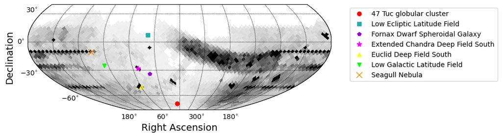

```python
fig, ax = plt.subplots(figsize=(8, 6))
sp = skyproj.McBrydeSkyproj(ax=ax)
vras = np.asarray(df['fieldRA'], dtype='float')
vdecs = np.asarray(df['fieldDec'], dtype='float')
sp.draw_hpxbin(vras, vdecs, nside=19, alpha=1, cmap='Greys', vmin=-10)
for i in range(len(dp1_field_names)):
    sp.ax.plot(dp1_field_ras[i], dp1_field_decs[i], dp1_field_symbols[i], ms=dp1_field_symsizes[i],
               color=dp1_field_colors[i], label=dp1_field_names[i])
sp.ax.set_xlabel("Right Ascension", fontsize=14)
sp.ax.set_ylabel("Declination", fontsize=14)
plt.legend(bbox_to_anchor=(1.05, 1), loc='upper left')
plt.show()
```

> **Figure 9:** Same as Figure 8, but with the seven DP1 LSSTComCam fields marked.

## 7. Exercises for the learner

Of the columns in the commissioning visits database, only nine were mentioned as key columns in Section 2.1. This did not include the column `cloud_extinction`.

Review the description of the `cloud_extinction` on the [Science Validation survey summary webpage](https://survey-strategy.lsst.io/progress/sv_status/sv_20250930.html) :

> The visit database *"also includes an estimate of the mean cloud extinction in the images. These are estimates based on the measured zeropoints for the images, compared to the expected zeropoint for an image in that bandpass at that airmass. A potential issue here is that visits with very heavy cloud extinction (or other problem with the quicklook image processing occuring immediately after image acquisition) may not succeed in measuring a zeropoint for the image at all, and thus no estimate for the cloud extinction will be possible either."*